# TMDB Dataset Investigation -Judah Sleibi

## Importing used libraries:

```python
# Import used libraries
import pandas as pd
import numpy as np
import json
import matplotlib.pyplot as plt
import missingno as misgo
import seaborn as sns
```

## Dataset reading:

```python
# Load the dataset from CSV file
Dataframe = pd.read_csv('tmdb-movies.csv')
Dataframe.head(3)
```

|  | id | imdb_id | popularity | budget | revenue | original_title | cast | homepage | director | tagline | ... | overview | runtime | genres | production_companies | release_date | vote_count | vote_average | release_year | budget_adj | revenue_adj |
| --- | --- | --- | --- | --- | --- | --- | --- | --- | --- | --- | --- | --- | --- | --- | --- | --- | --- | --- | --- | --- | --- |
| 0 | 135397 | tt0369610 | 32.985763 | 150000000 | 1513528810 | Jurassic World | Chris Pratt\|Bryce Dallas Howard\|Irrfan Khan\|Vi... | http://www.jurassicworld.com/ | Colin Trevorrow | The park is open. | ... | Twenty-two years after the events of Jurassic ... | 124 | Action\|Adventure\|Science Fiction\|Thriller | Universal Studios\|Amblin Entertainment\|Legenda... | 6/9/15 | 5562 | 6.5 | 2015 | 1.379999e+08 | 1.392446e+09 |
| 1 | 76341 | tt1392190 | 28.419936 | 150000000 | 378436354 | Mad Max: Fury Road | Tom Hardy\|Charlize Theron\|Hugh Keays-Byrne\|Nic... | http://www.madmaxmovie.com/ | George Miller | What a Lovely Day. | ... | An apocalyptic story set in the furthest reach... | 120 | Action\|Adventure\|Science Fiction\|Thriller | Village Roadshow Pictures\|Kennedy Miller Produ... | 5/13/15 | 6185 | 7.1 | 2015 | 1.379999e+08 | 3.481613e+08 |
| 2 | 262500 | tt2908446 | 13.112507 | 110000000 | 295238201 | Insurgent | Shailene Woodley\|Theo James\|Kate Winslet\|Ansel... | http://www.thedivergentseries.movie/#insurgent | Robert Schwentke | One Choice Can Destroy You | ... | Beatrice Prior must confront her inner demons ... | 119 | Adventure\|Science Fiction\|Thriller | Summit Entertainment\|Mandeville Films\|Red Wago... | 3/18/15 | 2480 | 6.3 | 2015 | 1.012000e+08 | 2.716190e+08 |

3 rows × 21 columns

```python
# Get the shape of the dataset (rows, columns)
Dataframe.shape
```

```
(10866, 21)
```

## Introduction and Description of the Data

This dataset provides information about movies from the TMDb *The Movie Database*, including various features related to each film, such as budget, revenue, cast, director, popularity, etc. The dataset consists of 10,866 entries and 21 columns.

## Dataset Overview

1. **id** - Unique identifier for the movie.
2. **imdb_id** - IMDb identifier for the movie.
3. **popularity** - Numeric score indicating movie popularity.
4. **budget** - Production budget (in USD).
5. **revenue** - Total revenue generated (in USD).
6. **original_title** - Original title of the movie.
7. **cast** - List of main actors.
8. **homepage** - Official website (if available).
9. **director** - Director's name.
10. **tagline** - Promotional tagline.
11. **keywords** - Keywords associated with the movie.
12. **overview** - Short summary of the movie.
13. **runtime** - Duration (in minutes).
14. **genres** - Movie genres (e.g., Action, Comedy).
15. **production_companies** - Companies involved in production.
16. **release_date** - Movie’s release date.
17. **vote_count** - Number of votes received.
18. **vote_average** - Average rating.
19. **release_year** - Year of release.
20. **budget_adj** - Budget adjusted for inflation.
21. **revenue_adj** - Revenue adjusted for inflation.

## Checking dataset entries, null values counts and types:

```python
# Summary information about the dataset
Dataframe.info()
```

```
<class 'pandas.core.frame.DataFrame'>
RangeIndex: 10866 entries, 0 to 10865
Data columns (total 21 columns):
 #   Column                Non-Null Count  Dtype
---  ------                --------------  -----
 0   id                    10866 non-null  int64
 1   imdb_id               10856 non-null  object
 2   popularity            10866 non-null  float64
 3   budget                10866 non-null  int64
 4   revenue               10866 non-null  int64
 5   original_title        10866 non-null  object
 6   cast                  10790 non-null  object
 7   homepage              2936 non-null   object
 8   director              10822 non-null  object
 9   tagline               8042 non-null   object
 10  keywords              9373 non-null   object
 11  overview              10862 non-null  object
 12  runtime               10866 non-null  int64
 13  genres                10843 non-null  object
 14  production_companies  9836 non-null   object
 15  release_date          10866 non-null  object
 16  vote_count            10866 non-null  int64
 17  vote_average          10866 non-null  float64
 18  release_year          10866 non-null  int64
 19  budget_adj            10866 non-null  float64
 20  revenue_adj           10866 non-null  float64
dtypes: float64(4), int64(6), object(11)
memory usage: 1.7+ MB
```

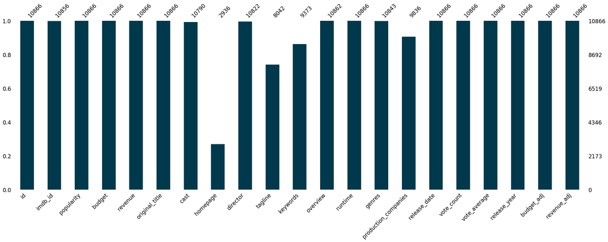

```python
# Visualizing missing values in the dataset
misgo.bar(Dataframe, color='#01394c')
plt.tight_layout()
```

### id column:

Starting with renaming the column name.

```python
# Renaming column with new meaningful name
Dataframe.rename(columns={'id': 'ID'}, inplace=True)
```

Inspecting the first five rows of the column:

```python
# Displaying the first five rows of the dataframe
Dataframe['ID'].head(5)
```

```
0    135397
1     76341
2    262500
3    140607
4    168259
Name: ID, dtype: int64
```

```python
# Generating statistical description
Dataframe['ID'].describe()
```

```
count     10866.000000
mean      66064.177434
std       92130.136561
min           5.000000
25%       10596.250000
50%       20669.000000
75%       75610.000000
max      417859.000000
Name: ID, dtype: float64
```

```python
# Changing the type of the data from float64 into float32 saving more memory
Dataframe['ID'] = Dataframe['ID'].astype('float32')
```

Checking for null or missing values:

```python
# Number of null values
print("Number of null values: " +str(Dataframe['ID'].isna().sum()))
```

```
Number of null values: 0
```

```python
# Histogram function to avoid repetition :
def plot_histogram(data, column_name, bins=10, color='#01394c', title='Histogram', xlabel='Value', ylabel='Frequency'):

    plt.figure(figsize=(10, 7))
    plt.hist(data[column_name], bins=bins, color=color)
    plt.title(title)
    plt.xlabel(xlabel)
    plt.ylabel(ylabel)
    plt.show()
```

Plotting the data as histogram to observe the distribution:

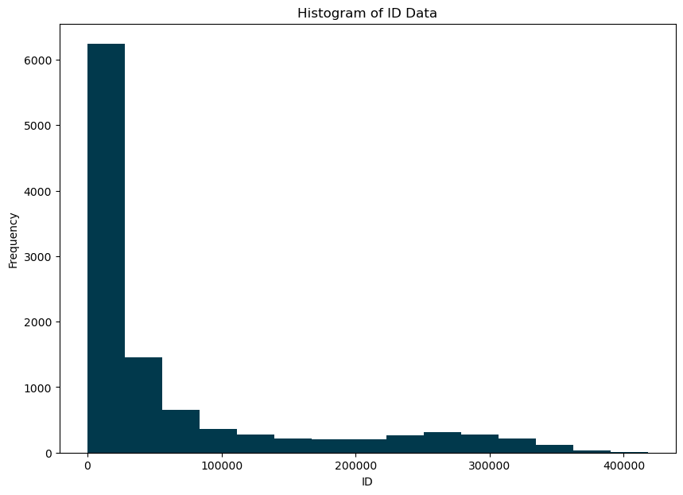

```python
# Plotting the histogram
plot_histogram(Dataframe, 'ID', bins=15, title='Histogram of ID Data', xlabel='ID', ylabel='Frequency')
```

Results explained:

1. The histogram is right-skewed, meaning most of the data are concentrated in the lower range, while fewer values extend towards the higher range.

### imdb_id column:

```python
# Renaming column with new meaningful name
Dataframe.rename(columns={'imdb_id': 'IMDB ID'}, inplace=True)
```

Inspecting the first five rows of the column:

```python
# Displaying the first five rows of the dataframe
Dataframe['IMDB ID'].head(5)
```

```
0    tt0369610
1    tt1392190
2    tt2908446
3    tt2488496
4    tt2820852
Name: IMDB ID, dtype: object
```

Extracting numbers from the invalid data

```python
# Extracting int values form strings
Dataframe['IMDB ID'] = Dataframe['IMDB ID'].str.extract(r'(\d+)')
```

Inspecting the first five rows of the column:

```python
# Displaying the first five rows of the dataframe
Dataframe['IMDB ID'].head(5)
```

```
0    0369610
1    1392190
2    2908446
3    2488496
4    2820852
Name: IMDB ID, dtype: object
```

```python
# Changing the type of the data into float64
Dataframe['IMDB ID'] = Dataframe['IMDB ID'].astype('float64')
```

```python
# Generating statistical description
Dataframe['IMDB ID'].describe()
```

```
count    1.085600e+04
mean     9.414629e+05
std      1.042664e+06
min      3.542300e+04
25%      1.126902e+05
50%      4.200355e+05
75%      1.558814e+06
max      6.019206e+06
Name: IMDB ID, dtype: float64
```

The maximum value of IMDB ID column is **6019206** which is smaller than 2^32 **429 496 7296**, so instead of using the float64 for storing we can use float32 minimizing the memory storage.

```python
# Changing the type of the data from float64 into float32 saving more memory
Dataframe['IMDB ID'] = Dataframe['IMDB ID'].astype('float32')
```

Checking for null or missing values:

```python
# Number of null values
print("Number of null values: " +str(Dataframe['IMDB ID'].isna().sum()))
```

```
Number of null values: 10
```

Plotting the data as histogram to observe the distribution:

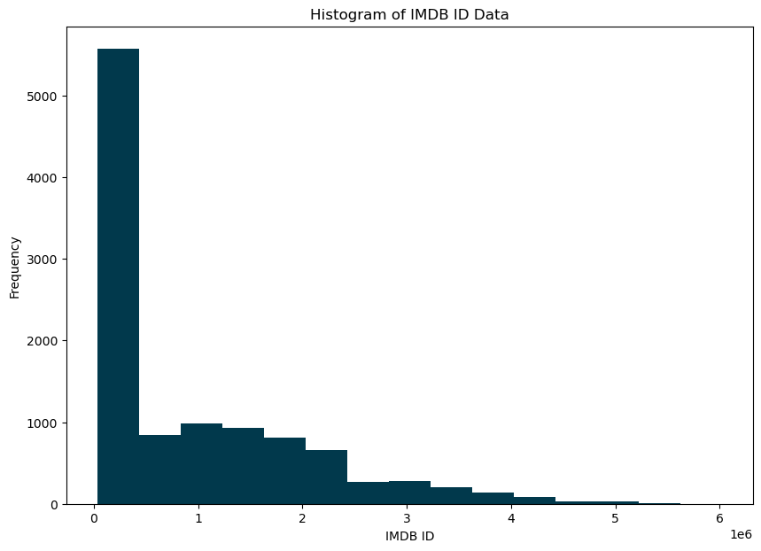

```python
# Plotting the histogram
plot_histogram(Dataframe, 'IMDB ID', bins=15, title='Histogram of IMDB ID Data', xlabel='IMDB ID', ylabel='Frequency')
```

Results explained:

1. The histogram is highly right-skewed.
2. Most values are at the lower range, while fewer values extend to the higher range.

## popularity column:

```python
# Renaming column with new meaningful name
Dataframe.rename(columns={'popularity': 'Popularity'}, inplace=True)
```

```python
# Displaying the first five rows of the dataframe
Dataframe['Popularity'].head(5)
```

```
0    32.985763
1    28.419936
2    13.112507
3    11.173104
4     9.335014
Name: Popularity, dtype: float64
```

```python
# Generating statistical description
Dataframe['Popularity'].describe()
```

```
count    10866.000000
mean         0.646441
std          1.000185
min          0.000065
25%          0.207583
50%          0.383856
75%          0.713817
max         32.985763
Name: Popularity, dtype: float64
```

The maximum value of Popularity column is **32.985763** which is smaller than 2^32 **429 496 7296**, so instead of using the float64 for storing we can use float16 minimizing the memory storage.

```python
# Changing the type of the data from float64 into float16 saving more memory
Dataframe['Popularity'] = Dataframe['Popularity'].astype('float16')
```

Checking for null or missing values:

```python
# Number of null values
print("Number of null values: " +str(Dataframe['Popularity'].isna().sum()))
```

```
Number of null values: 0
```

Plotting the data as histogram to observe the distribution:

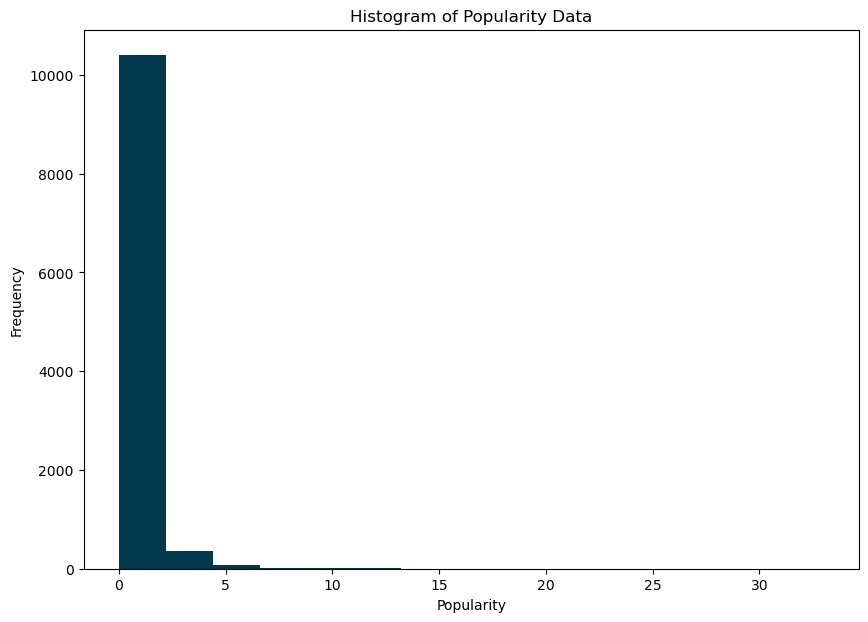

```python
# Plotting the histogram
plot_histogram(Dataframe, 'Popularity', bins=15, title='Histogram of Popularity Data', xlabel='Popularity', ylabel='Frequency')
```

Results explained:

1. The data appears to be highly right-skewed.
2. Most of the values are concentrated near zero, with a few extreme values extending further along the x-axis.
3. There are very few data points beyond a popularity score of 5 meaning that only a small number of movies have high popularity.

### budget column:

Starting with renaming the column name.

```python
# Renaming column with new meaningful name
Dataframe.rename(columns={'budget': 'Budget'}, inplace=True)
```

Inspecting the first five rows of the column:

```python
# Displaying the first five rows of the dataframe
Dataframe['Budget'].head(5)
```

```
0    150000000
1    150000000
2    110000000
3    200000000
4    190000000
Name: Budget, dtype: int64
```

Creating descriptive statistics about the feature:

```python
# Generating statistical description
Dataframe['Budget'].describe()
```

```
count    1.086600e+04
mean     1.462570e+07
std      3.091321e+07
min      0.000000e+00
25%      0.000000e+00
50%      0.000000e+00
75%      1.500000e+07
max      4.250000e+08
Name: Budget, dtype: float64
```

The maximum value of Budget column is **425 000 000** which is smaller than 2^32 **429 496 7296**, so instead of using the int64 for storing we can use int32 minimizing the memory storage.

```python
# Changing the type of the data from int64 into uint32 saving more memory
Dataframe['Budget'] = Dataframe['Budget'].astype('uint32')
```

Checking for null or missing values:

```python
# Number of null values
print("Number of null values: " +str(Dataframe['Budget'].isna().sum()))
```

```
Number of null values: 0
```

Plotting the data as histogram to observe the distribution:

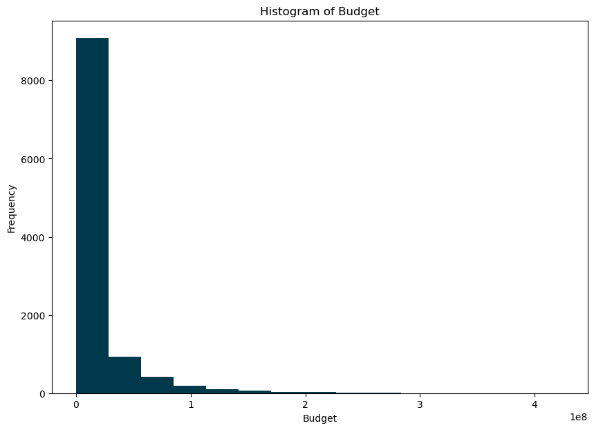

```python
# Plotting the histogram
plot_histogram(Dataframe, 'Budget', bins=15, title='Histogram of Budget', xlabel='Budget', ylabel='Frequency')
```

Results explained:

1. The budget data is highly positively skewed where most movies have very low budgets, while a few have extremely high budgets.
2. A small number of movies have a very high budgets.

### revenue column:

Starting with renaming the column.

```python
# Renaming column with new meaningful name
Dataframe.rename(columns={'revenue': 'Revenue'}, inplace=True)
```

Inspecting the first five rows of the column:

```python
# Displaying the first five rows of the dataframe
Dataframe['Revenue'].head(5)
```

```
0    1513528810
1     378436354
2     295238201
3    2068178225
4    1506249360
Name: Revenue, dtype: int64
```

Creating descriptive statistics about the feature:

```python
# Generating statistical description
Dataframe['Revenue'].describe()
```

```
count    1.086600e+04
mean     3.982332e+07
std      1.170035e+08
min      0.000000e+00
25%      0.000000e+00
50%      0.000000e+00
75%      2.400000e+07
max      2.781506e+09
Name: Revenue, dtype: float64
```

Checking unique and missing entries:

```python
# Number of null values
print("Number of null values: " +str(Dataframe['Revenue'].isna().sum()))
```

```
Number of null values: 0
```

```python
# Number of unique values
print("Unique entries count: " + str(len(Dataframe['Revenue'].unique())))
```

```
Unique entries count: 4702
```

The maximum value of Revenue column is **278 1506 000** which is smaller than 2^32 **429 4967 296**, so instead of using the float64 for storing we can use float32 minimizing the memory storage.

```python
# Changing the type of the data from float64 into float32 saving more memory
Dataframe['Revenue'] = Dataframe['Revenue'].astype('float32')
```

Plotting the data as histogram to observe the distribution:

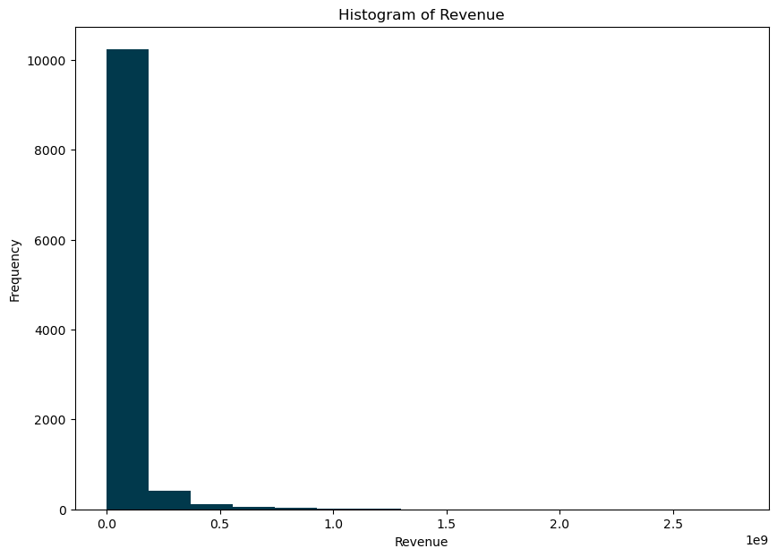

```python
# Plotting the histogram
plot_histogram(Dataframe, 'Revenue', bins=15, title='Histogram of Revenue', xlabel='Revenue', ylabel='Frequency')
```

Results explained:

1. most movies have low revenues, while a few have extremely high revenues.
2. A small number of movies have very high revenues.

### original_title column:

Starting with renaming the column.

```python
# Renaming column with new meaningful name
Dataframe.rename(columns={'original_title': 'Original title'}, inplace=True)
```

Inspecting the first five rows of the column:

```python
# Displaying the first five rows of the dataframe
Dataframe['Original title'].head(5)
```

```
0                  Jurassic World
1              Mad Max: Fury Road
2                       Insurgent
3    Star Wars: The Force Awakens
4                       Furious 7
Name: Original title, dtype: object
```

Creating descriptive statistics about the feature:

```python
# Generating statistical description
Dataframe['Original title'].describe()
```

```
count      10866
unique     10571
top       Hamlet
freq           4
Name: Original title, dtype: object
```

Checking unique and missing entries:

```python
# Number of null values
print("Number of null values: " +str(Dataframe['Original title'].isna().sum()))
```

```
Number of null values: 0
```

```python
# Number of unique values
print("Unique entries count: " + str(len(Dataframe['Original title'].unique())))
```

```
Unique entries count: 10571
```

```python
# Changing the type of the data into string to save more memory
Dataframe['Original title'] = Dataframe['Original title'].astype('str')
```

### cast column:

Starting with renaming the column.

```python
# Renaming column with new meaningful name
Dataframe.rename(columns={'cast': 'Cast'}, inplace=True)
```

Inspecting the first five rows of the column:

```python
# Displaying the first five rows of the dataframe
Dataframe['Cast'].head(5)
```

```
0    Chris Pratt|Bryce Dallas Howard|Irrfan Khan|Vi...
1    Tom Hardy|Charlize Theron|Hugh Keays-Byrne|Nic...
2    Shailene Woodley|Theo James|Kate Winslet|Ansel...
3    Harrison Ford|Mark Hamill|Carrie Fisher|Adam D...
4    Vin Diesel|Paul Walker|Jason Statham|Michelle ...
Name: Cast, dtype: object
```

Creating descriptive statistics about the feature:

```python
# Generating statistical description
Dataframe['Cast'].describe()
```

```
count          10790
unique         10719
top       Louis C.K.
freq               6
Name: Cast, dtype: object
```

Checking unique and missing entries:

```python
# Number of null values
print("Number of null values: " +str(Dataframe['Cast'].isna().sum()))
```

```
Number of null values: 76
```

```python
# Number of unique values
print("Unique entries count: " + str(len(Dataframe['Cast'].unique())))
```

```
Unique entries count: 10720
```

```python
# Changing the type of the data into string saving more memory
Dataframe['Cast'] = Dataframe['Cast'].astype('str')
```

### homepage column:

Starting with renaming the column.

```python
# Renaming column with new meaningful name
Dataframe.rename(columns={'homepage': 'Homepage URL'}, inplace=True)
```

Inspecting the first five rows of the column:

```python
# Displaying the first five rows of the dataframe
Dataframe['Homepage URL'].head(5)
```

```
0                        http://www.jurassicworld.com/
1                          http://www.madmaxmovie.com/
2       http://www.thedivergentseries.movie/#insurgent
3    http://www.starwars.com/films/star-wars-episod...
4                             http://www.furious7.com/
Name: Homepage URL, dtype: object
```

Creating descriptive statistics about the feature:

```python
# Generating statistical description
Dataframe['Homepage URL'].describe()
```

```
count                                 2936
unique                                2896
top       http://www.thehungergames.movie/
freq                                     4
Name: Homepage URL, dtype: object
```

Checking unique and missing entries:

```python
# Number of null values
print("Number of null values: " +str(Dataframe['Homepage URL'].isna().sum()))
```

```
Number of null values: 7930
```

```python
# Number of unique values
print("Unique entries count: " + str(len(Dataframe['Homepage URL'].unique())))
```

```
Unique entries count: 2897
```

```python
# Changing the type of the data into string saving more memory
Dataframe['Homepage URL'] = Dataframe['Homepage URL'].astype('str')
```

### director column:

Starting with renaming the column.

```python
# Renaming column with new meaningful name
Dataframe.rename(columns={'director': 'Director'}, inplace=True)
```

Inspecting the first five rows of the column:

```python
# Displaying the first five rows of the dataframe
Dataframe['Director'].head(5)
```

```
0     Colin Trevorrow
1       George Miller
2    Robert Schwentke
3         J.J. Abrams
4           James Wan
Name: Director, dtype: object
```

Creating descriptive statistics about the feature:

```python
# Generating statistical description
Dataframe['Director'].describe()
```

```
count           10822
unique           5067
top       Woody Allen
freq               45
Name: Director, dtype: object
```

Checking unique and missing entries:

```python
# Number of null values
print("Number of null values: " +str(Dataframe['Director'].isna().sum()))
```

```
Number of null values: 44
```

```python
# Number of unique values
print("Unique entries count: " + str(len(Dataframe['Director'].unique())))
```

```
Unique entries count: 5068
```

```python
# Changing the type of the data into string saving more memory
Dataframe['Director'] = Dataframe['Director'].astype('str')
```

### tagline column:

Starting with renaming the column.

```python
# Renaming column with new meaningful name
Dataframe.rename(columns={'tagline': 'Tag line'}, inplace=True)
```

Inspecting the first five rows of the column:

```python
# Displaying the first five rows of the dataframe
Dataframe['Tag line'].head(5)
```

```
0                The park is open.
1               What a Lovely Day.
2       One Choice Can Destroy You
3    Every generation has a story.
4              Vengeance Hits Home
Name: Tag line, dtype: object
```

Creating descriptive statistics about the feature:

```python
# Generating statistical description
Dataframe['Tag line'].describe()
```

```
count                       8042
unique                      7997
top       Based on a true story.
freq                           5
Name: Tag line, dtype: object
```

Checking unique and missing entries:

```python
# Number of null values
print("Number of null values: " +str(Dataframe['Tag line'].isna().sum()))
```

```
Number of null values: 2824
```

```python
# Number of unique values
print("Unique entries count: " + str(len(Dataframe['Tag line'].unique())))
```

```
Unique entries count: 7998
```

```python
# Changing the type of the data into string saving more memory
Dataframe['Tag line'] = Dataframe['Tag line'].astype('str')
```

### keywords column:

Starting with renaming the column.

```python
# Renaming column with new meaningful name
Dataframe.rename(columns={'keywords': 'Keywords'}, inplace=True)
```

Inspecting the first five rows of the column:

```python
# Displaying the first five rows of the dataframe
Dataframe['Keywords'].head(5)
```

```
0    monster|dna|tyrannosaurus rex|velociraptor|island
1     future|chase|post-apocalyptic|dystopia|australia
2    based on novel|revolution|dystopia|sequel|dyst...
3                android|spaceship|jedi|space opera|3d
4                  car race|speed|revenge|suspense|car
Name: Keywords, dtype: object
```

Creating descriptive statistics about the feature:

```python
# Generating statistical description
Dataframe['Keywords'].describe()
```

```
count               9373
unique              8804
top       woman director
freq                 134
Name: Keywords, dtype: object
```

Checking unique and missing entries:

```python
# Number of null values
print("Number of null values: " +str(Dataframe['Keywords'].isna().sum()))
```

```
Number of null values: 1493
```

```python
# Number of unique values
print("Unique entries count: " + str(len(Dataframe['Keywords'].unique())))
```

```
Unique entries count: 8805
```

```python
# Changing the type of the data into string saving more memory
Dataframe['Keywords'] = Dataframe['Keywords'].astype('str')
```

### overview column:

Starting with renaming the column.

```python
# Renaming column with new meaningful name
Dataframe.rename(columns={'overview': 'Overview'}, inplace=True)
```

Inspecting the first five rows of the column:

```python
# Displaying the first five rows of the dataframe
Dataframe['Overview'].head(5)
```

```
0    Twenty-two years after the events of Jurassic ...
1    An apocalyptic story set in the furthest reach...
2    Beatrice Prior must confront her inner demons ...
3    Thirty years after defeating the Galactic Empi...
4    Deckard Shaw seeks revenge against Dominic Tor...
Name: Overview, dtype: object
```

Creating descriptive statistics about the feature:

```python
# Generating statistical description
Dataframe['Overview'].describe()
```

```
count                  10862
unique                 10847
top       No overview found.
freq                      13
Name: Overview, dtype: object
```

Checking unique and missing entries:

```python
# Number of null values
print("Number of null values: " +str(Dataframe['Overview'].isna().sum()))
```

```
Number of null values: 4
```

```python
# Number of unique values
print("Unique entries count: " + str(len(Dataframe['Overview'].unique())))
```

```
Unique entries count: 10848
```

```python
# Changing the type of the data into string saving more memory
Dataframe['Overview'] = Dataframe['Overview'].astype('str')
```

### runtime column:

Starting with renaming the column.

```python
# Renaming column with new meaningful name
Dataframe.rename(columns={'runtime': 'Run time'}, inplace=True)
```

Inspecting the first five rows of the column:

```python
# Displaying the first five rows of the dataframe
Dataframe['Run time'].head(5)
```

```
0    124
1    120
2    119
3    136
4    137
Name: Run time, dtype: int64
```

Creating descriptive statistics about the feature:

```python
# Generating statistical description
Dataframe['Run time'].describe()
```

```
count    10866.000000
mean       102.070863
std         31.381405
min          0.000000
25%         90.000000
50%         99.000000
75%        111.000000
max        900.000000
Name: Run time, dtype: float64
```

Checking unique and missing entries:

```python
# Number of null values
print("Number of null values: " +str(Dataframe['Run time'].isna().sum()))
```

```
Number of null values: 0
```

```python
# Number of unique values
print("Unique entries count: " + str(len(Dataframe['Run time'].unique())))
```

```
Unique entries count: 247
```

The maximum value of Run time column is **900.000000** which is smaller than 2^32 **429 4967 296**, so instead of using the float64 for storing we can use float16 minimizing the memory storage.

```python
# Changing the type of the data from float64 into float16 saving more memory
Dataframe['Run time'] = Dataframe['Run time'].astype('float16')
```

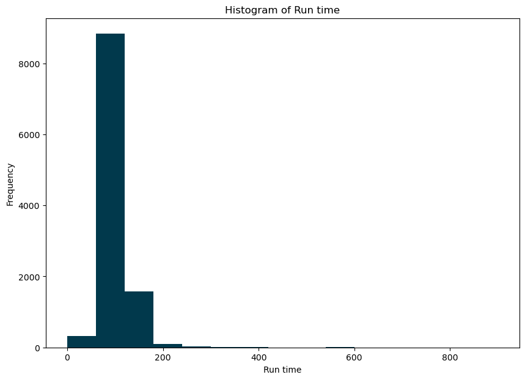

```python
# Plotting the histogram
plot_histogram(Dataframe, 'Run time', bins=15, title='Histogram of Run time', xlabel='Run time', ylabel='Frequency')
```

Results explained:

1. Most movies have a runtime below 200 minutes, with very few exceeding 200 minutes.
2. The majority of movies fall within 0 and 200 minutes.
3. The presence of very short or very long run times might indicate anomalies or errors in the dataset.

### genres column:

Starting with renaming the column.

```python
# Renaming column with new meaningful name
Dataframe.rename(columns={'genres': 'Genres'}, inplace=True)
```

Inspecting the first five rows of the column:

```python
# Displaying the first five rows of the dataframe
Dataframe['Genres'].head(5)
```

```
0    Action|Adventure|Science Fiction|Thriller
1    Action|Adventure|Science Fiction|Thriller
2           Adventure|Science Fiction|Thriller
3     Action|Adventure|Science Fiction|Fantasy
4                        Action|Crime|Thriller
Name: Genres, dtype: object
```

Creating descriptive statistics about the feature:

```python
# Generating statistical description
Dataframe['Genres'].describe()
```

```
count      10843
unique      2039
top       Comedy
freq         712
Name: Genres, dtype: object
```

Checking unique and missing entries:

```python
# Number of null values
print("Number of null values: " +str(Dataframe['Genres'].isna().sum()))
```

```
Number of null values: 23
```

```python
# Number of unique values
print("Unique entries count: " + str(len(Dataframe['Genres'].unique())))
```

```
Unique entries count: 2040
```

```python
# Changing the type of the data into string saving more memory
Dataframe['Genres'].astype('str')
```

```
0        Action|Adventure|Science Fiction|Thriller
1        Action|Adventure|Science Fiction|Thriller
2               Adventure|Science Fiction|Thriller
3         Action|Adventure|Science Fiction|Fantasy
4                            Action|Crime|Thriller
                           ...
10861                                  Documentary
10862                       Action|Adventure|Drama
10863                               Mystery|Comedy
10864                                Action|Comedy
10865                                       Horror
Name: Genres, Length: 10866, dtype: object
```

### production_companies column:

Starting with renaming the column.

```python
# Renaming column with new meaningful name
Dataframe.rename(columns={'production_companies': 'Production companies'}, inplace=True)
```

Inspecting the first five rows of the column:

```python
# Displaying the first five rows of the dataframe
Dataframe['Production companies'].head(5)
```

```
0    Universal Studios|Amblin Entertainment|Legenda...
1    Village Roadshow Pictures|Kennedy Miller Produ...
2    Summit Entertainment|Mandeville Films|Red Wago...
3            Lucasfilm|Truenorth Productions|Bad Robot
4    Universal Pictures|Original Film|Media Rights ...
Name: Production companies, dtype: object
```

Creating descriptive statistics about the feature:

```python
# Generating statistical description
Dataframe['Production companies'].describe()
```

```
count                   9836
unique                  7445
top       Paramount Pictures
freq                     156
Name: Production companies, dtype: object
```

Checking unique and missing entries:

```python
# Number of null values
print("Number of null values: " +str(Dataframe['Production companies'].isna().sum()))
```

```
Number of null values: 1030
```

```python
# Number of unique values
print("Unique entries count: " + str(len(Dataframe['Production companies'].unique())))
```

```
Unique entries count: 7446
```

```python
# Changing the type of the data into string saving more memory
Dataframe['Production companies'] = Dataframe['Production companies'].astype('str')
```

### release_date column:

Starting with renaming the column.

```python
# Renaming column with new meaningful name
Dataframe.rename(columns={'release_date': 'Release date'}, inplace=True)
```

Inspecting the first five rows of the column:

```python
# Displaying the first five rows of the dataframe
Dataframe['Release date'].head(5)
```

```
0      6/9/15
1     5/13/15
2     3/18/15
3    12/15/15
4      4/1/15
Name: Release date, dtype: object
```

Creating descriptive statistics about the feature:

```python
# Generating statistical description
Dataframe['Release date'].describe()
```

```
count      10866
unique      5909
top       1/1/09
freq          28
Name: Release date, dtype: object
```

Checking unique and missing entries:

```python
# Number of null values
print("Number of null values: " +str(Dataframe['Release date'].isna().sum()))
```

```
Number of null values: 0
```

```python
# Number of unique values
print("Unique entries count: " + str(len(Dataframe['Release date'].unique())))
```

```
Unique entries count: 5909
```

```python
# Changing the type of the data into date saving more memory
Dataframe['Release date'] = pd.to_datetime(Dataframe['Release date'])
```

### vote_count column:

Starting with renaming the column.

```python
# Renaming column with new meaningful name
Dataframe.rename(columns={'vote_count': 'Vote count'}, inplace=True)
```

Inspecting the first five rows of the column:

```python
# Displaying the first five rows of the dataframe
Dataframe['Vote count'].head(5)
```

```
0    5562
1    6185
2    2480
3    5292
4    2947
Name: Vote count, dtype: int64
```

Creating descriptive statistics about the feature:

```python
# Generating statistical description
Dataframe['Vote count'].describe()
```

```
count    10866.000000
mean       217.389748
std        575.619058
min         10.000000
25%         17.000000
50%         38.000000
75%        145.750000
max       9767.000000
Name: Vote count, dtype: float64
```

Checking unique and missing entries:

```python
# Number of null values
print("Number of null values: " +str(Dataframe['Vote count'].isna().sum()))
```

```
Number of null values: 0
```

```python
# Number of unique values
print("Unique entries count: " + str(len(Dataframe['Vote count'].unique())))
```

```
Unique entries count: 1289
```

The maximum value of Vote count column is **9767** which is smaller than 2^32 **429 4967 296**, so instead of using the float64 for storing we can use float16 minimizing the memory storage.

```python
# Changing the type of the data from float64 into float16 saving more memory
Dataframe['Vote count'] = Dataframe['Vote count'].astype('float16')
```

Plotting the data as histogram to observe the distribution:

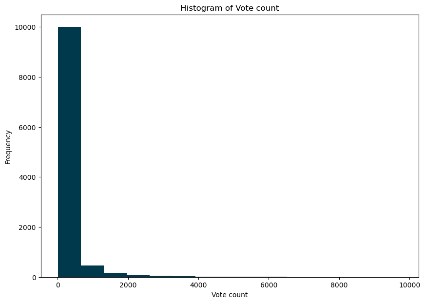

```python
# Plotting the histogram
plot_histogram(Dataframe, 'Vote count', bins=15, title='Histogram of Vote count', xlabel='Vote count', ylabel='Frequency')
```

Results explained:

1. The majority of movies have very low vote counts.
2. A few movies have significantly higher vote counts.
3. Most movies receive relatively few votes, possibly indicating that many are less popular or have limited viewership.

### vote_average column

Starting with renaming the column.

```python
# Renaming column with new meaningful name
Dataframe.rename(columns={'vote_average': 'Vote average'}, inplace=True)
```

Inspecting the first five rows of the column:

```python
# Displaying the first five rows of the dataframe
Dataframe['Vote average'].head(5)
```

```
0    6.5
1    7.1
2    6.3
3    7.5
4    7.3
Name: Vote average, dtype: float64
```

Creating descriptive statistics about the feature:

```python
# Generating statistical description
Dataframe['Vote average'].describe()
```

```
count    10866.000000
mean         5.974922
std          0.935142
min          1.500000
25%          5.400000
50%          6.000000
75%          6.600000
max          9.200000
Name: Vote average, dtype: float64
```

Checking unique and missing entries:

```python
# Number of null values
print("Number of null values: " +str(Dataframe['Vote average'].isna().sum()))
```

```
Number of null values: 0
```

```python
# Number of unique values
print("Unique entries count: " + str(len(Dataframe['Vote average'].unique())))
```

```
Unique entries count: 72
```

```python
# Changing the type of the data from float64 into float16 saving more memory
Dataframe['Vote average'] = Dataframe['Vote average'].astype('float16')
```

Plotting the data as histogram to observe the distribution:

[figure not shown]

```python
# Plotting the histogram
plot_histogram(Dataframe, 'Vote count', bins=15, title='Histogram of Vote average', xlabel='Vote average', ylabel='Frequency')
```

### release_year column:

Starting with renaming the column.

```python
# Renaming column with new meaningful name
Dataframe.rename(columns={'release_year': 'Release year'}, inplace=True)
```

Inspecting the first five rows of the column:

```python
# Displaying the first five rows of the dataframe
Dataframe['Release year'].head(5)
```

```
0    2015
1    2015
2    2015
3    2015
4    2015
Name: Release year, dtype: int64
```

Creating descriptive statistics about the feature:

```python
# Generating statistical description
Dataframe['Release year'].describe()
```

```
count    10866.000000
mean      2001.322658
std         12.812941
min       1960.000000
25%       1995.000000
50%       2006.000000
75%       2011.000000
max       2015.000000
Name: Release year, dtype: float64
```

Checking unique and missing entries:

```python
# Number of null values
print("Number of null values: " +str(Dataframe['Release year'].isna().sum()))
```

```
Number of null values: 0
```

```python
# Number of unique values
print("Unique entries count: " + str(len(Dataframe['Release year'].unique())))
```

```
Unique entries count: 56
```

The maximum value of Release year column is **2015** which is smaller than 2^16 **65536**, so instead of using the float64 for storing we can use int16 minimizing the memory storage.

```python
# Changing the type of the data from float64 into int16 saving more memory
Dataframe['Release year'] = Dataframe['Release year'].astype('int16')
```

Plotting the data as histogram to observe the distribution:

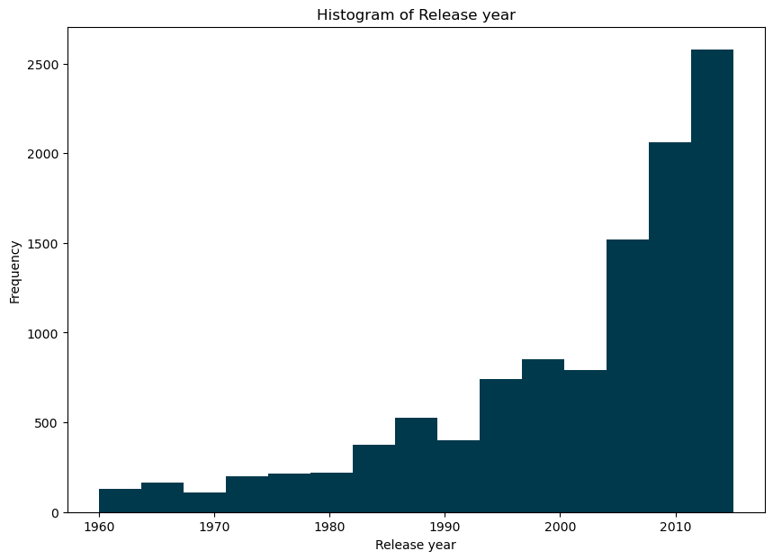

```python
# Plotting the histogram
plot_histogram(Dataframe, 'Release year', bins=15, title='Histogram of Release year', xlabel='Release year', ylabel='Frequency')
```

### budget_adj column:

Starting with renaming the column.

```python
# Renaming column with new meaningful name
Dataframe.rename(columns={'budget_adj': 'Budget adjusted'}, inplace=True)
```

Inspecting the first five rows of the column:

```python
# Displaying the first five rows of the dataframe
Dataframe['Budget adjusted'].head(5)
```

```
0    1.379999e+08
1    1.379999e+08
2    1.012000e+08
3    1.839999e+08
4    1.747999e+08
Name: Budget adjusted, dtype: float64
```

Creating descriptive statistics about the feature:

```python
# Generating statistical description
Dataframe['Budget adjusted'].describe()
```

```
count    1.086600e+04
mean     1.755104e+07
std      3.430616e+07
min      0.000000e+00
25%      0.000000e+00
50%      0.000000e+00
75%      2.085325e+07
max      4.250000e+08
Name: Budget adjusted, dtype: float64
```

Checking unique and missing entries:

```python
# Number of null values
print("Number of null values: " +str(Dataframe['Budget adjusted'].isna().sum()))
```

```
Number of null values: 0
```

```python
# Number of unique values
print("Unique entries count: " + str(len(Dataframe['Budget adjusted'].unique())))
```

```
Unique entries count: 2614
```

```python
# Changing the type of the data from float64 into float32 saving more memory
Dataframe['Budget adj'] = Dataframe['Budget adjusted'].astype('float32')
```

Plotting the data as histogram to observe the distribution:

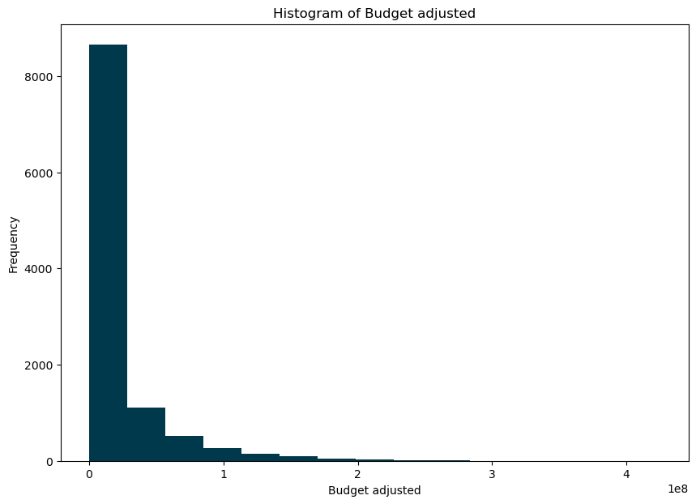

```python
# Plotting the histogram
plot_histogram(Dataframe, 'Budget adjusted', bins=15, title='Histogram of Budget adjusted', xlabel='Budget adjusted', ylabel='Frequency')
```

Results explained:

1. right-skewed.
2. Most Movies Have Low Budgets.
3. Few Movies Have Huge Budgets.
4. istribution is not uniform.

### revenue_adj column:

Starting with renaming the column.

```python
# Renaming column with new meaningful name
Dataframe.rename(columns={'revenue_adj': 'Revenue adjusted'}, inplace=True)
```

Inspecting the first five rows of the column:

```python
# Displaying the first five rows of the dataframe
Dataframe['Revenue adjusted'].head(5)
```

```
0    1.392446e+09
1    3.481613e+08
2    2.716190e+08
3    1.902723e+09
4    1.385749e+09
Name: Revenue adjusted, dtype: float64
```

Creating descriptive statistics about the feature:

```python
# Generating statistical description
Dataframe['Revenue adjusted'].describe()
```

```
count    1.086600e+04
mean     5.136436e+07
std      1.446325e+08
min      0.000000e+00
25%      0.000000e+00
50%      0.000000e+00
75%      3.369710e+07
max      2.827124e+09
Name: Revenue adjusted, dtype: float64
```

Checking unique and missing entries:

```python
# Number of null values
print("Number of null values: " +str(Dataframe['Revenue adjusted'].isna().sum()))
```

```
Number of null values: 0
```

```python
# Number of unique values
print("Unique entries count: " + str(len(Dataframe['Revenue adjusted'].unique())))
```

```
Unique entries count: 4840
```

Plotting the data as histogram to observe the distribution:

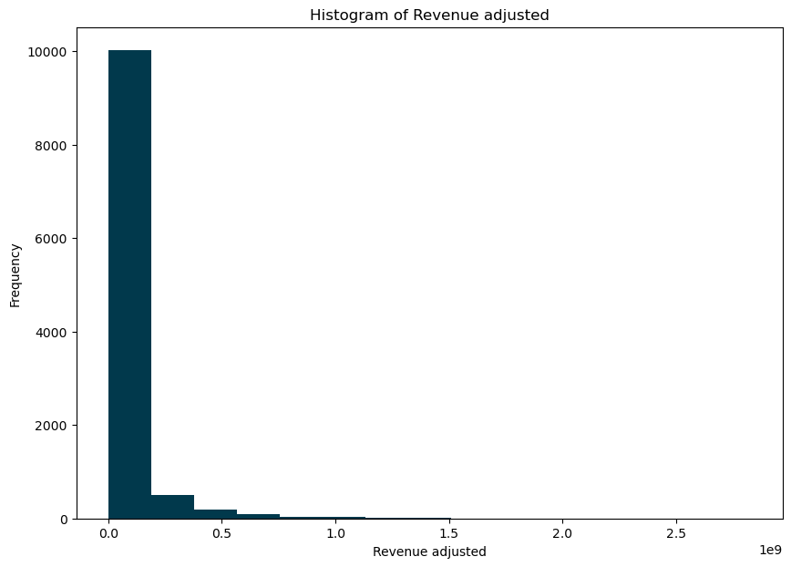

```python
# Plotting the histogram
plot_histogram(Dataframe, 'Revenue adjusted', bins=15, title='Histogram of Revenue adjusted', xlabel='Revenue adjusted', ylabel='Frequency')
```

Results explained:

1. Most movies earn very little.
2. A few movies earn high Revenue.
3. Extreme right skewness.

### IMDB Number column:

Inspecting the first five rows of the column:

```python
Dataframe.info()
```

```
<class 'pandas.core.frame.DataFrame'>
RangeIndex: 10866 entries, 0 to 10865
Data columns (total 22 columns):
 #   Column                Non-Null Count  Dtype
---  ------                --------------  -----
 0   ID                    10866 non-null  float32
 1   IMDB ID               10856 non-null  float32
 2   Popularity            10866 non-null  float16
 3   Budget                10866 non-null  uint32
 4   Revenue               10866 non-null  float32
 5   Original title        10866 non-null  object
 6   Cast                  10866 non-null  object
 7   Homepage URL          10866 non-null  object
 8   Director              10866 non-null  object
 9   Tag line              10866 non-null  object
 10  Keywords              10866 non-null  object
 11  Overview              10866 non-null  object
 12  Run time              10866 non-null  float16
 13  Genres                10843 non-null  object
 14  Production companies  10866 non-null  object
 15  Release date          10866 non-null  datetime64[ns]
 16  Vote count            10866 non-null  float16
 17  Vote average          10866 non-null  float16
 18  Release year          10866 non-null  int16
 19  Budget adjusted       10866 non-null  float64
 20  Revenue adjusted      10866 non-null  float64
 21  Budget adj            10866 non-null  float32
dtypes: datetime64[ns](1), float16(4), float32(4), float64(2), int16(1), object(9), uint32(1)
memory usage: 1.3+ MB
```

```python
Dataframe.head()
```

|  | ID | IMDB ID | Popularity | Budget | Revenue | Original title | Cast | Homepage URL | Director | Tag line | ... | Run time | Genres | Production companies | Release date | Vote count | Vote average | Release year | Budget adjusted | Revenue adjusted | Budget adj |
| --- | --- | --- | --- | --- | --- | --- | --- | --- | --- | --- | --- | --- | --- | --- | --- | --- | --- | --- | --- | --- | --- |
| 0 | 135397.0 | 369610.0 | 33.000000 | 150000000 | 1.513529e+09 | Jurassic World | Chris Pratt\|Bryce Dallas Howard\|Irrfan Khan\|Vi... | http://www.jurassicworld.com/ | Colin Trevorrow | The park is open. | ... | 124.0 | Action\|Adventure\|Science Fiction\|Thriller | Universal Studios\|Amblin Entertainment\|Legenda... | 2015-06-09 | 5560.0 | 6.500000 | 2015 | 1.379999e+08 | 1.392446e+09 | 137999936.0 |
| 1 | 76341.0 | 1392190.0 | 28.421875 | 150000000 | 3.784364e+08 | Mad Max: Fury Road | Tom Hardy\|Charlize Theron\|Hugh Keays-Byrne\|Nic... | http://www.madmaxmovie.com/ | George Miller | What a Lovely Day. | ... | 120.0 | Action\|Adventure\|Science Fiction\|Thriller | Village Roadshow Pictures\|Kennedy Miller Produ... | 2015-05-13 | 6184.0 | 7.101562 | 2015 | 1.379999e+08 | 3.481613e+08 | 137999936.0 |
| 2 | 262500.0 | 2908446.0 | 13.109375 | 110000000 | 2.952382e+08 | Insurgent | Shailene Woodley\|Theo James\|Kate Winslet\|Ansel... | http://www.thedivergentseries.movie/#insurgent | Robert Schwentke | One Choice Can Destroy You | ... | 119.0 | Adventure\|Science Fiction\|Thriller | Summit Entertainment\|Mandeville Films\|Red Wago... | 2015-03-18 | 2480.0 | 6.300781 | 2015 | 1.012000e+08 | 2.716190e+08 | 101199952.0 |
| 3 | 140607.0 | 2488496.0 | 11.171875 | 200000000 | 2.068178e+09 | Star Wars: The Force Awakens | Harrison Ford\|Mark Hamill\|Carrie Fisher\|Adam D... | http://www.starwars.com/films/star-wars-episod... | J.J. Abrams | Every generation has a story. | ... | 136.0 | Action\|Adventure\|Science Fiction\|Fantasy | Lucasfilm\|Truenorth Productions\|Bad Robot | 2015-12-15 | 5292.0 | 7.500000 | 2015 | 1.839999e+08 | 1.902723e+09 | 183999920.0 |
| 4 | 168259.0 | 2820852.0 | 9.335938 | 190000000 | 1.506249e+09 | Furious 7 | Vin Diesel\|Paul Walker\|Jason Statham\|Michelle ... | http://www.furious7.com/ | James Wan | Vengeance Hits Home | ... | 137.0 | Action\|Crime\|Thriller | Universal Pictures\|Original Film\|Media Rights ... | 2015-04-01 | 2948.0 | 7.300781 | 2015 | 1.747999e+08 | 1.385749e+09 | 174799920.0 |

5 rows × 22 columns

## Most popular movie?

```python
# Inspecting the row that contains the highest Popularity
popular_column = Dataframe.loc[Dataframe['Popularity'].idxmax()]
print(popular_column)
```

```
ID                                                               135397.0
IMDB ID                                                          369610.0
Popularity                                                           33.0
Budget                                                          150000000
Revenue                                                      1513528832.0
Original title                                             Jurassic World
Cast                    Chris Pratt|Bryce Dallas Howard|Irrfan Khan|Vi...
Homepage URL                                http://www.jurassicworld.com/
Director                                                  Colin Trevorrow
Tag line                                                The park is open.
Keywords                monster|dna|tyrannosaurus rex|velociraptor|island
Overview                Twenty-two years after the events of Jurassic ...
Run time                                                            124.0
Genres                          Action|Adventure|Science Fiction|Thriller
Production companies    Universal Studios|Amblin Entertainment|Legenda...
Release date                                          2015-06-09 00:00:00
Vote count                                                         5560.0
Vote average                                                          6.5
Release year                                                         2015
Budget adjusted                                          137999939.280026
Revenue adjusted                                          1392445892.5238
Budget adj                                                    137999936.0
Name: 0, dtype: object
```

```python
# Storing a feature in a variable
Mostpopular_cost = popular_column['Budget']
```

## Is the most popular film the most expensive?

```python
# Inspecting the row that contains the most expensive film
Max = Dataframe.loc[Dataframe['Budget'].idxmax()]
print(Max)
```

```
ID                                                                46528.0
IMDB ID                                                         1032751.0
Popularity                                                       0.250488
Budget                                                          425000000
Revenue                                                        11087569.0
Original title                                          The Warrior's Way
Cast                    Kate Bosworth|Jang Dong-gun|Geoffrey Rush|Dann...
Homepage URL                       http://www.iamrogue.com/thewarriorsway
Director                                                       Sngmoo Lee
Tag line                                          Assassin. Hero. Legend.
Keywords                assassin|small town|revenge|deception|super speed
Overview                An Asian assassin (Dong-gun Jang) is forced to...
Run time                                                            100.0
Genres                          Adventure|Fantasy|Action|Western|Thriller
Production companies                             Boram Entertainment Inc.
Release date                                          2010-12-02 00:00:00
Vote count                                                           74.0
Vote average                                                     6.398438
Release year                                                         2010
Budget adjusted                                               425000000.0
Revenue adjusted                                               11087569.0
Budget adj                                                    425000000.0
Name: 2244, dtype: object
```

```python
# Storing a feature in a variable
Highestfilm_cost = Max['Budget']
```

```python
print("Is the most popular film the most expensive?")
if(Mostpopular_cost > Highestfilm_cost):
    print("Yes")
else:
    print("No")
```

```
Is the most popular film the most expensive?
No
```

Answer:  
The most popular film is not the most expensive.

```python
Mostpopular_Revenue = popular_column['Revenue']
Highestfilm_Revenue= Max['Budget']
```

```python
print("Is the most popular film is the highest revenue. ")
if(Mostpopular_Revenue > Highestfilm_Revenue):
    print("Yes")
else:
    print("No")
```

[output not shown]

```python
Mostpopular_Director = popular_column['Director']
print("Director name: " + str(Mostpopular_Director))
```

```
Director name: Colin Trevorrow
```

```python
Dataframe_Colin_Trevorrow = Dataframe[Dataframe['Director'] == 'Colin Trevorrow']
Dataframe_Colin_Trevorrow
```

|  | ID | IMDB ID | Popularity | Budget | Revenue | Original title | Cast | Homepage URL | Director | Tag line | ... | Run time | Genres | Production companies | Release date | Vote count | Vote average | Release year | Budget adjusted | Revenue adjusted | Budget adj |
| --- | --- | --- | --- | --- | --- | --- | --- | --- | --- | --- | --- | --- | --- | --- | --- | --- | --- | --- | --- | --- | --- |
| 0 | 135397.0 | 369610.0 | 33.000000 | 150000000 | 1.513529e+09 | Jurassic World | Chris Pratt\|Bryce Dallas Howard\|Irrfan Khan\|Vi... | http://www.jurassicworld.com/ | Colin Trevorrow | The park is open. | ... | 124.0 | Action\|Adventure\|Science Fiction\|Thriller | Universal Studios\|Amblin Entertainment\|Legenda... | 2015-06-09 | 5560.0 | 6.500000 | 2015 | 1.379999e+08 | 1.392446e+09 | 1.379999e+08 |
| 4604 | 84332.0 | 1862079.0 | 0.407959 | 750000 | 4.007792e+06 | Safety Not Guaranteed | Aubrey Plaza\|Mark Duplass\|Jake Johnson\|Karan S... | nan | Colin Trevorrow | What would you go back for? | ... | 85.0 | Comedy\|Romance\|Science Fiction\|Drama | Duplass Brothers Productions\|Big Beach Films | 2012-06-08 | 341.0 | 6.699219 | 2012 | 7.123082e+05 | 3.806378e+06 | 7.123082e+05 |

2 rows × 22 columns

Films for the same Director have bais in the Revenue and Budget, director does not insure all films to have the highest revenue.

## Is there a relation between Time and Revenue?

```python
# Checking the correlation betweeen the two features
Correlation_checking = Dataframe['Run time'].corr(Dataframe['Revenue'])
print("Correlation ratio: " + str(Correlation_checking))
```

```
Correlation ratio: 0.16283788977127206
```

The corolation is positive but week

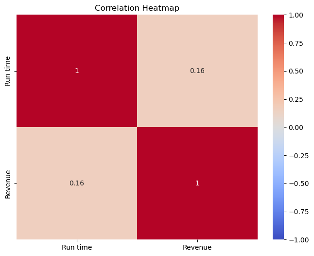

```python
corr_matrix = Dataframe[['Run time', 'Revenue']].corr()
plt.figure(figsize=(8, 6))
sns.heatmap(corr_matrix, annot=True, cmap='coolwarm', vmin=-1, vmax=1, center=0)

plt.title('Correlation Heatmap')
plt.show()
```

```python
Dataframe.info()
```

```
<class 'pandas.core.frame.DataFrame'>
RangeIndex: 10866 entries, 0 to 10865
Data columns (total 22 columns):
 #   Column                Non-Null Count  Dtype
---  ------                --------------  -----
 0   ID                    10866 non-null  float32
 1   IMDB ID               10856 non-null  float32
 2   Popularity            10866 non-null  float16
 3   Budget                10866 non-null  uint32
 4   Revenue               10866 non-null  float32
 5   Original title        10866 non-null  object
 6   Cast                  10866 non-null  object
 7   Homepage URL          10866 non-null  object
 8   Director              10866 non-null  object
 9   Tag line              10866 non-null  object
 10  Keywords              10866 non-null  object
 11  Overview              10866 non-null  object
 12  Run time              10866 non-null  float16
 13  Genres                10843 non-null  object
 14  Production companies  10866 non-null  object
 15  Release date          10866 non-null  datetime64[ns]
 16  Vote count            10866 non-null  float16
 17  Vote average          10866 non-null  float16
 18  Release year          10866 non-null  int16
 19  Budget adjusted       10866 non-null  float64
 20  Revenue adjusted      10866 non-null  float64
 21  Budget adj            10866 non-null  float32
dtypes: datetime64[ns](1), float16(4), float32(4), float64(2), int16(1), object(9), uint32(1)
memory usage: 1.3+ MB
```

```python
Dataframe.shape
```

```
(10866, 22)
```

## Data wrangling

The data has some missing values in different columns, the missing data can be handled using different methodologies the fastest one is dropping the null and missing values. But why? The data is not consistence in type so the replacement with the mean can't work with string values also the data is not distributed normally in general skewed more to the right side effecting the mean value and possibly result in wrong estimation.

```python
DataFrameNoNull = Dataframe.dropna()
print("Null values in DataFrame after the drop: " + str(DataFrameNoNull.isna().sum()))
```

```
Null values in DataFrame after the drop: ID                      0
IMDB ID                 0
Popularity              0
Budget                  0
Revenue                 0
Original title          0
Cast                    0
Homepage URL            0
Director                0
Tag line                0
Keywords                0
Overview                0
Run time                0
Genres                  0
Production companies    0
Release date            0
Vote count              0
Vote average            0
Release year            0
Budget adjusted         0
Revenue adjusted        0
Budget adj              0
dtype: int64
```

Also from the plots a presece of outliers can be found, to clean the data from possible outliers a drop function can be used as following:

### Budget

```python
Mean = DataFrameNoNull['Budget'].mean()
STD = DataFrameNoNull['Budget'].std()
SeriesOfData = DataFrameNoNull['Budget'].dropna()
ZScore = (SeriesOfData- Mean) / STD

print("Mean: ", Mean)
print("standard deviation: ",STD)
outliers = np.abs(SeriesOfData[abs(ZScore) > 3])
print("Outliers: \n", outliers)

NumberOfOutliers = len(outliers)
print("Number of rows containing outliers:", NumberOfOutliers)

valid_indices = DataFrameNoNull.index.intersection(outliers.index)
DataFrameNoNull = DataFrameNoNull[~DataFrameNoNull.index.isin(outliers.index)]
```

```
Mean:  14667546.154960776
standard deviation:  30947493.765092593
Outliers:
 0       150000000
1       150000000
2       110000000
3       200000000
4       190000000
          ...
8730    120000000
8970    140000000
8977    120000000
8995    140000000
8997    130000000
Name: Budget, Length: 266, dtype: uint32
Number of rows containing outliers: 266
```

### Revenue

```python
Mean = DataFrameNoNull['Revenue'].mean()
STD = DataFrameNoNull['Revenue'].std()
SeriesOfData = DataFrameNoNull['Revenue'].dropna()
ZScore = (SeriesOfData- Mean) / STD

print("Mean: ", Mean)
print("standard deviation: ",STD)
outliers = np.abs(SeriesOfData[abs(ZScore) > 3])
print("Outliers: \n", outliers)

NumberOfOutliers = len(outliers)
print("Number of rows containing outliers:", NumberOfOutliers)

valid_indices = DataFrameNoNull.index.intersection(outliers.index)
DataFrameNoNull = DataFrameNoNull[~DataFrameNoNull.index.isin(outliers.index)]
```

```
Mean:  28605096.0
standard deviation:  75365536.0
Outliers:
 8        1.156731e+09
16       3.257714e+08
18       5.423514e+08
23       5.696515e+08
27       4.038021e+08
             ...
10312    2.666141e+08
10475    3.568306e+08
10499    3.282035e+08
10594    4.413061e+08
10758    3.002180e+08
Name: Revenue, Length: 227, dtype: float32
Number of rows containing outliers: 227
```

### Run time

```python
Mean = DataFrameNoNull['Run time'].mean()
STD = DataFrameNoNull['Run time'].std()
SeriesOfData = DataFrameNoNull['Run time'].dropna()
ZScore = (SeriesOfData- Mean) / STD

print("Mean: ", Mean)
print("standard deviation: ",STD)
outliers = np.abs(SeriesOfData[abs(ZScore) > 3])
print("Outliers: \n", outliers)

NumberOfOutliers = len(outliers)
print("Number of rows containing outliers:", NumberOfOutliers)

valid_indices = DataFrameNoNull.index.intersection(outliers.index)
DataFrameNoNull = DataFrameNoNull[~DataFrameNoNull.index.isin(outliers.index)]
```

```
Mean:  inf
standard deviation:  inf
Outliers:
 Series([], Name: Run time, dtype: float16)
Number of rows containing outliers: 0
```

The data set contains high numbers causing overflow.

### Vote count

```python
Mean = DataFrameNoNull['Vote count'].mean()
STD = DataFrameNoNull['Vote count'].std()
SeriesOfData = DataFrameNoNull['Vote count'].dropna()
ZScore = (SeriesOfData- Mean) / STD

print("Mean: ", Mean)
print("standard deviation: ",STD)
outliers = np.abs(SeriesOfData[abs(ZScore) > 3])
print("Outliers: \n", outliers)

NumberOfOutliers = len(outliers)
print("Number of rows containing outliers:", NumberOfOutliers)

valid_indices = DataFrameNoNull.index.intersection(outliers.index)
DataFrameNoNull = DataFrameNoNull[~DataFrameNoNull.index.isin(outliers.index)]
```

```
Mean:  inf
standard deviation:  inf
Outliers:
 Series([], Name: Vote count, dtype: float16)
Number of rows containing outliers: 0
```

The data set contains high numbers causing overflow.

### Budget adjusted

```python
Mean = DataFrameNoNull['Budget adjusted'].mean()
STD = DataFrameNoNull['Budget adjusted'].std()
SeriesOfData = DataFrameNoNull['Budget adjusted'].dropna()
ZScore = (SeriesOfData- Mean) / STD

print("Mean: ", Mean)
print("standard deviation: ",STD)
outliers = np.abs(SeriesOfData[abs(ZScore) > 3])
print("Outliers: \n", outliers)

NumberOfOutliers = len(outliers)
print("Number of rows containing outliers:", NumberOfOutliers)

valid_indices = DataFrameNoNull.index.intersection(outliers.index)
DataFrameNoNull = DataFrameNoNull[~DataFrameNoNull.index.isin(outliers.index)]
```

```
Mean:  12698596.205430191
standard deviation:  23165730.85090406
Outliers:
 41       8.279996e+07
54       9.659996e+07
66       9.199996e+07
76       9.107996e+07
665      8.289819e+07
             ...
10665    8.424553e+07
10684    1.404092e+08
10691    9.688789e+07
10716    1.384113e+08
10824    1.209243e+08
Name: Budget adjusted, Length: 279, dtype: float64
Number of rows containing outliers: 279
```

### Revenue adjusted

```python
Mean = DataFrameNoNull['Revenue adjusted'].mean()
STD = DataFrameNoNull['Revenue adjusted'].std()
SeriesOfData = DataFrameNoNull['Revenue adjusted'].dropna()
ZScore = (SeriesOfData- Mean) / STD

print("Mean: ", Mean)
print("standard deviation: ",STD)
outliers = np.abs(SeriesOfData[abs(ZScore) > 3])
print("Outliers: \n", outliers)

NumberOfOutliers = len(outliers)
print("Number of rows containing outliers:", NumberOfOutliers)

valid_indices = DataFrameNoNull.index.intersection(outliers.index)
DataFrameNoNull = DataFrameNoNull[~DataFrameNoNull.index.isin(outliers.index)]
```

```
Mean:  25902116.409990888
standard deviation:  68323242.51777005
Outliers:
 1330     6.671677e+08
1331     2.562191e+08
1340     8.530813e+08
1342     4.559735e+08
1381     3.669737e+08
             ...
10755    6.077490e+08
10756    6.280400e+08
10759    2.339890e+08
10760    4.713208e+08
10819    2.607307e+08
Name: Revenue adjusted, Length: 181, dtype: float64
Number of rows containing outliers: 181
```

```python
DataFrameNoNull.drop('Budget adj', axis=1, inplace=True)
```

```python
DataFrameNoNull.shape
```

```
(9882, 21)
```

```python
DataFrameNoNull.info()
```

```
<class 'pandas.core.frame.DataFrame'>
Index: 9882 entries, 12 to 10865
Data columns (total 21 columns):
 #   Column                Non-Null Count  Dtype
---  ------                --------------  -----
 0   ID                    9882 non-null   float32
 1   IMDB ID               9882 non-null   float32
 2   Popularity            9882 non-null   float16
 3   Budget                9882 non-null   uint32
 4   Revenue               9882 non-null   float32
 5   Original title        9882 non-null   object
 6   Cast                  9882 non-null   object
 7   Homepage URL          9882 non-null   object
 8   Director              9882 non-null   object
 9   Tag line              9882 non-null   object
 10  Keywords              9882 non-null   object
 11  Overview              9882 non-null   object
 12  Run time              9882 non-null   float16
 13  Genres                9882 non-null   object
 14  Production companies  9882 non-null   object
 15  Release date          9882 non-null   datetime64[ns]
 16  Vote count            9882 non-null   float16
 17  Vote average          9882 non-null   float16
 18  Release year          9882 non-null   int16
 19  Budget adjusted       9882 non-null   float64
 20  Revenue adjusted      9882 non-null   float64
dtypes: datetime64[ns](1), float16(4), float32(3), float64(2), int16(1), object(9), uint32(1)
memory usage: 1.2+ MB
```